# HW_TextMining

Bhushan

February 1, 2016

### Text Analytics

Using the package **rvest** one can download web pages. Let us Extract text from them and pull the MD&A, which is the description of the Management Discussion and Analysis inside the 10-K filing. We will do this for any one stock ticker(Groupon) . You may find the 10-K filings at the EDGAR web site provided by the SEC. In the MD&A just grab only the overview paragraphs preceding the Sales Data. Print out a clean paragraph, i.e., write code to clean up the strange characters in the text.

#### Answer:

We have used following packages: - rvest - slam - tm - wordcloud - lsa - Rcurl - XML - stringr - igraph - topicmodels

We read the 10K’s using **read_html()** function and extract the particular text using html_node().

```r
#Read the 10K's for Groupon
htmlpage <- read_html("https://www.sec.gov/Archives/edgar/data/1490281/000144530512000922/groupon10-k.htm#s510FC9A31D5A3D1BAD2560B662E0F3F9")

#We extract all the paragraphs present under MD&A using n-th child attribute
overview <- htmlpage%>%
  html_node("div:nth-child(785)")%>%
  html_text()

p2 <- htmlpage%>%
  html_node("div:nth-child(786)")%>%
  html_text()

p3 <- htmlpage%>%
  html_node("div:nth-child(787)")%>%
  html_text()

p4 <- htmlpage%>%
  html_node("div:nth-child(788)")%>%
  html_text()

text = c(overview,p2,p3,p4)

text = paste(text,collapse=" ")
print(text)
```

```
## [1] "Groupon is a local commerce marketplace that connects merchant partners to consumers by offering goods and services at a discount. Traditionally, local merchants have tried to reach consumers and generate sales through a variety of methods, including the yellow pages, direct mail, newspaper,…
```

Let us check how many sentences are there in the extracted text. We will summarize the extracted text into 1/4 of its current length in terms of representative sentences using Jaccard Similarity.

#### Answer:

```r
#Split them on ". " to get count of number of sentences.
text2 = strsplit(text,". ",fixed=TRUE)
#print(text2)
totalSentences = length(text2[[1]])
print(totalSentences)
```

```
## [1] 17
```

```r
mText = text2[[1]]

#We are performing the jaccard similarity on text without any modification

summaryLength = as.integer(totalSentences/4)
print(summaryLength)
```

```
## [1] 4
```

```r
text_summary = function(text, n) {
  m = length(text)  # No of sentences in input
  jaccard = matrix(0,m,m)  #Store match index
  for (i in 1:m) {
    for (j in i:m) {
      a = text[i]; aa = unlist(strsplit(a," "))
      b = text[j]; bb = unlist(strsplit(b," "))
      jaccard[i,j] = length(intersect(aa,bb))/
                          length(union(aa,bb))
      jaccard[j,i] = jaccard[i,j]
    }
  }
  similarity_score = rowSums(jaccard)
  res = sort(similarity_score, index.return=TRUE,
          decreasing=TRUE)
  idx = res$ix[1:n]
  summary = text[idx]
}

ctextCos = Corpus(VectorSource(mText))
ctextCos = tm_map(ctextCos, removeWords, stopwords("english"))
ctextCos = tm_map(ctextCos, removePunctuation)
ctextCos = tm_map(ctextCos, removePunctuation)
ctextCos = tm_map(ctextCos,content_transformer(tolower))

updatedTextJac = NULL
for (j in 1:length(ctextCos)) {
  temp = ctextCos[[j]]$content
    if (temp!="") { updatedTextJac = c(updatedTextJac,temp) }
    }
updatedTextJac = as.array(updatedTextJac)

summarizedText = text_summary(updatedTextJac,summaryLength)
print(summarizedText)
```

```
## [1] "revenue   international operations  1125â million  9755â million  2010  2011 respectively"
## [2] "for  year ended december 31 2010  derived 360   revenue   international segment compared  606   year ended december 31 2011"
## [3] "  the increases  revenue  partially due   rapid international expansion  2010"
## [4] " in 2011  generated revenue   16104 million compared  3129 million  2010  145 million  2009"
```

### Wordcloud

Convert the sentences you created into a Corpus using the **tm** package. Each sentence will be a separate document in this corpus. Next, convert the corpus into a term-document matrix (TDM). From this prepare a wordcloud summarizing the corpus.

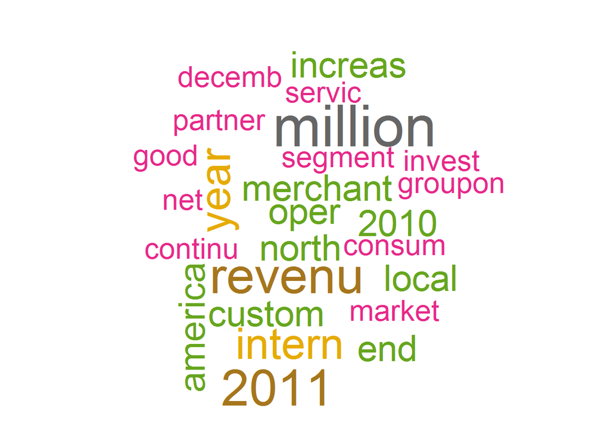

```r
ctext = Corpus(VectorSource(mText))
ctext = tm_map(ctext, content_transformer(tolower))
ctext = tm_map(ctext, removePunctuation)
ctext = tm_map(ctext, removeWords, stopwords("english"))
ctext = tm_map(ctext, stemDocument)

tdm = TermDocumentMatrix(ctext,control=list(minWordLength=1))
tdm2 = as.matrix(tdm)
wordcount = sort(rowSums(tdm2),decreasing=TRUE)
tdm_names = names(wordcount)
wordcloud(tdm_names,wordcount, colors=brewer.pal(8,"Dark2"))
```

We will use the TDM to find the matrix of cosine distances between all sentences. Then generate a new summary using cosine distances instead of Jaccard similarity as done previously. Compare the two results and comment.

```r
#We are performing the jaccard similarity on text without any modification

# We should also perform cosin on text without modification
text_summary_cosine = function(cosineM, text, n) {
  cosTotal = rowSums(cosineM)
  resC = sort(cosTotal, index.return=TRUE,
          decreasing=TRUE)
  idx = resC$ix[1:n]
  text[idx]
}

ctextCos = Corpus(VectorSource(mText))
ctextCos = tm_map(ctextCos, removeWords, stopwords("english"))
ctextCos = tm_map(ctextCos, removePunctuation)
ctextCos = tm_map(ctextCos, removePunctuation)
ctextCos = tm_map(ctextCos,content_transformer(tolower))

tdmCos = TermDocumentMatrix(ctextCos,control=list(minWordLength=1))

cosine_Mat = crossprod_simple_triplet_matrix(tdmCos)/(sqrt(col_sums(tdmCos^2) %*% t(col_sums(tdmCos^2))))

#print(cosine_Mat)
updatedTextCos = NULL
for (j in 1:length(ctextCos)) {
  temp = ctextCos[[j]]$content
    if (temp!="") { updatedTextCos = c(updatedTextCos,temp) }
    }
updatedTextCos = as.array(updatedTextCos)


cosineSummarizedText = text_summary_cosine(cosine_Mat,updatedTextCos,summaryLength)
print(cosineSummarizedText)
```

```
## [1] "for  year ended december 31 2010  derived 360   revenue   international segment compared  606   year ended december 31 2011"
## [2] "revenue   international operations  1125â million  9755â million  2010  2011 respectively"
## [3] "in particular  net loss   year ended decemberâ 31 2011  driven primarily   rapid expansion   international segment   year  involved investing heavily  upfront marketing sales  infrastructure related   build    operations  south korea australia japan  brazil"
## [4] "we incurred  net loss  2978â million   year ended decemberâ 31 2011    accumulated deficit  6987â million   december 31 2011"
```

Thus we see that both the methods have generated slightly different summary.

### Mood Scoring the Text

Mood score the MD&A from the stock you chose and see if it positive or negative.

#### Answer:

```r
getwd()
```

```
## [1] "C:/Users/Bhushan/Google Drive/Portfolio/Data Science and Business Analytics"
```

```r
setwd("C:/Users/Bhushan/Documents")
HIDict = readLines("inqdict.txt")
dict_pos = HIDict[grep("Pos",HIDict)]
poswords = NULL
for (s in dict_pos) {
  s = strsplit(s,"#")[[1]][1]
    poswords = c(poswords,strsplit(s," ")[[1]][1])
}
dict_neg = HIDict[grep("Neg",HIDict)]
negwords = NULL
for (s in dict_neg) {
    s = strsplit(s,"#")[[1]][1]
    negwords = c(negwords,strsplit(s," ")[[1]][1])
}
poswords = tolower(poswords)
negwords = tolower(negwords)

#Stemming was not done in this case, however it can be easily done using similar tm_map command.

#We create a bag of wprds first
updatedText = NULL
for (j in 1:length(ctext)) {
  temp = ctext[[j]]$content
    if (temp!="") { updatedText = c(updatedText,temp) }
    }
updatedText = as.array(updatedText)

unListed = unlist(strsplit(updatedText," "))
posmatch = match(unListed,poswords)
numposmatch = length(posmatch[which(posmatch>0)])
negmatch = match(unListed,negwords)
numnegmatch = length(negmatch[which(negmatch>0)])
print(c(numposmatch,numnegmatch))
```

```
## [1] 20  9
```

### Text analytics on an article.

Get the article at:

http://www.politico.com/magazine/story/2016/01/obama-biggest-achievements-213487?paginate=false

1. Clean up this article, and reduce it to sentences.
2. Then compute the Jaccard similarity across sentences, pairwise. Find the median Jaccard similarity score.
3. Then, treating each sentence as a node in a network, create the adjacency matrix of nodes (sentences) in the network, such that two nodes are connected if the Jaccard score is greater than the median, else the nodes are not connected. PLot the network.
4. Rank the sentences by their respective centrality scores. Create a summary of the top 1/10 of sentences by centrality score.

We will try to use any ideas you may have to glean “context” from it, or do an analysis of the article, such as summarize topics that it may be covering. (For example, look up topic analysis.)

```r
# download html
article = read_html("http://www.politico.com/magazine/story/2016/01/obama-biggest-achievements-213487?paginate=false")

# parse html and extract only paragraph elements
doc = htmlParse(article, asText=TRUE)
plain.text <- xpathSApply(doc, "//p", xmlValue)

storyT = plain.text
class(storyT)
```

```
## [1] "character"
```

```r
#Extract the useful parts of text by removing aurthor name and dates
storyT = storyT[6:108]

storyT = paste(storyT, collapse = "\n")
storyT = gsub("[\r\n]", "", storyT)
storyT <- gsub("[][]|[^[:ascii:]]", "", storyT, perl=T)

storySentences = strsplit(storyT,". ",fixed=TRUE)[[1]]
```

Perform below lines if you want to compute jaccard similarity after removing stopwords

```r
storyCorpus = Corpus(VectorSource(storySentences))
storyCorpus = tm_map(storyCorpus,removePunctuation)
storyCorpus = tm_map(storyCorpus,removeWords, stopwords("english"))
storyCorpus = tm_map(storyCorpus,content_transformer(tolower))
storyCorpus = tm_map(storyCorpus,stemDocument)
storyCorpus = tm_map(storyCorpus, stripWhitespace)
#convert to array of strings
txt = NULL
for (j in 1:length(storyCorpus)) {
  txt = c(txt,storyCorpus[[j]]$content)
}

storySentences2 = txt
length(storySentences2)
```

```
## [1] 185
```

Create Jaccard matrix and find median of that matrix. then create a Adjacency matix based on the conditions specified in the question and plot a graph.

```r
#n is the number of sentences present
n = length(storySentences2)

print(n)
```

```
## [1] 185
```

```r
#Here n is length of array
calculateJaccard = function(text, n){
  m = length(text)  # No of sentences in input
  jaccard = matrix(0,m,n)  #Store match index
  for (i in 1:m) {
    for (j in i:m) {
      a = text[i]; aa = unlist(strsplit(a," "))
      b = text[j]; bb = unlist(strsplit(b," "))
      jaccard[i,j] = length(intersect(aa,bb))/
                          length(union(aa,bb))
      jaccard[j,i] = jaccard[i,j]
    }
  }
  jaccard
}

#create jaccard matrix using calculate function
jaccardM = calculateJaccard(storySentences,n)

#If we want to generate jaccard for cleaned up text use storySentences2

#Here we find median over entire matrix as we want to find the median jaccard similarity score between 2 sentences
medianJacc = median(jaccardM)
print(medianJacc)
```

```
## [1] 0.04166667
```

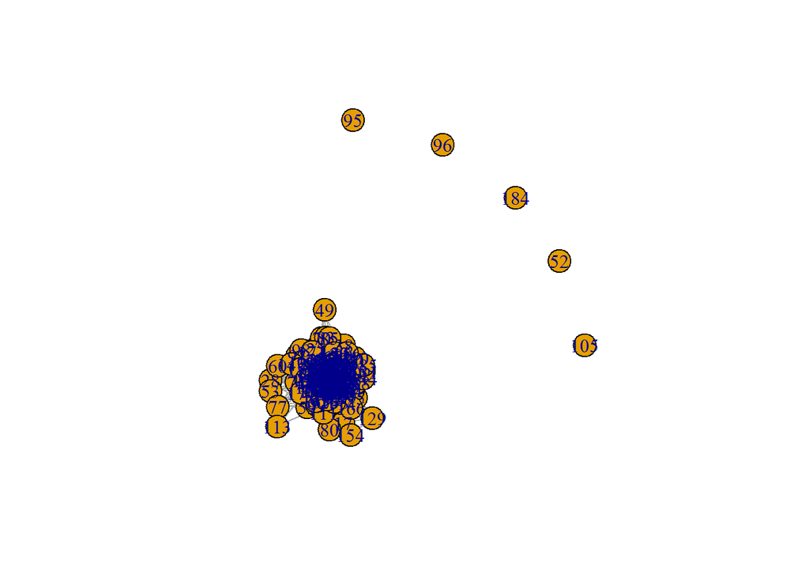

```r
#We define a function which will generate a adjacency matrix based on the condition of median.
adjacencyM = function(jaccardMat,n,median){
  m = n
  adjMat = matrix(0,m,n)
  for(i in 1:n){
    for(j in i:m){
      if(i!=j & jaccardMat[i,j]>median){
        adjMat[i,j] = 1
        adjMat[j,i] = 1
      }
    }
  }
  adjMat
}


adjMat = adjacencyM(jaccardM,n,medianJacc)
net=graph.adjacency(adjmatrix=adjMat,mode="undirected",weighted=TRUE,diag=FALSE)
plot(net)
```

Calculate centrality scores and obtain a summary.

```r
#Calculate centrality
centR = evcent(net)
centR
```

```
## $vector
##   [1] 0.39754372 0.40867058 0.90595037 0.94419609 0.81168733 0.82123958
##   [7] 0.79336356 0.84319487 0.53779704 0.62186626 0.78409025 0.85618326
##  [13] 0.97885438 0.88628027 0.88833348 0.95260486 0.09525311 0.54007082
##  [19] 0.76069831 0.50040807 0.88213052 0.78773555 0.51850250 0.90456532
##  [25] 0.26272720 0.51373110 0.83057461 0.05750163 0.75818165 0.79412757
##  [31] 0.96975871 0.87859072 0.68231719 0.81117790 0.73500538 0.94016390
##  [37] 0.67649486 0.30627106 0.64203600 0.83842630 0.88430244 0.82105576
##  [43] 0.38422654 0.91570040 0.70439483 0.86036592 0.92791245 0.69448103
##  [49] 0.03465484 0.66578147 0.59279932 0.00369614 0.03953513 0.80156605
##  [55] 0.74689771 0.84912209 0.86297948 0.92151623 0.21021195 0.07233242
##  [61] 0.48569959 0.69260796 0.61629279 1.00000000 0.80653246 0.63231503
##  [67] 0.47901641 0.86466720 0.81039883 0.16121933 0.87959054 0.90025915
##  [73] 0.70403980 0.20007878 0.29292527 0.83785702 0.04533140 0.88522563
##  [79] 0.93174083 0.08929679 0.94795177 0.79829704 0.22501146 0.93452671
##  [85] 0.22865818 0.73854747 0.38015928 0.41349443 0.69173457 0.42249265
##  [91] 0.86341741 0.59758139 0.91875518 0.41000045 0.00369614 0.00369614
##  [97] 0.15185780 0.12471913 0.32447776 0.82828636 0.86416442 0.30273997
## [103] 0.87686665 0.78643087 0.00369614 0.87216786 0.47535764 0.88450210
## [109] 0.21292455 0.23346249 0.20859354 0.70620409 0.01837809 0.39996822
## [115] 0.92468156 0.86594350 0.83011730 0.56143260 0.84086781 0.49162357
## [121] 0.83546747 0.58876949 0.65323407 0.65394960 0.77874848 0.82754053
## [127] 0.61545685 0.63210058 0.06175519 0.90443668 0.27261834 0.52266303
## [133] 0.63145469 0.90845052 0.55591880 0.83037120 0.83771449 0.41071075
## [139] 0.98036327 0.85080789 0.58905696 0.53805026 0.79872087 0.24699781
## [145] 0.67750198 0.88005985 0.14965425 0.87492601 0.91501696 0.51819730
## [151] 0.33663779 0.58394706 0.54598349 0.05596195 0.80194465 0.43903915
## [157] 0.54871519 0.70410634 0.94299028 0.78053371 0.66882418 0.88425301
## [163] 0.36161148 0.92302784 0.59543208 0.17588909 0.84688539 0.52340526
## [169] 0.80462746 0.96039162 0.29752825 0.77246136 0.78146258 0.86643221
## [175] 0.56765666 0.78010185 0.25723779 0.79718989 0.80106210 0.91605178
## [181] 0.67792692 0.84434036 0.87971954 0.00369614 0.27268187
##
## $value
## [1] 107.5566
##
## $options
## $options$bmat
## [1] "I"
##
```

[output cut: 41 more lines]

```
##
## $options$iter
## [1] 1
##
## $options$nconv
## [1] 1
##
## $options$numop
## [1] 20
##
## $options$numopb
## [1] 0
##
## $options$numreo
## [1] 12
```

```r
#obtain indices of sentences based on descending centrality scores
centrVec = sort(centR$vector, index.return=TRUE,
          decreasing=TRUE)
idx = centrVec$ix[1:n]

oneTenth = as.integer(n/10)
summary = storySentences[idx]

print(summary[1:oneTenth])
```

```
##  [1] "Health care inflation and the uninsured rate have fallen to their lowest levels in half a century, and doctors now use iPads instead of clipboards"
##  [2] "Meanwhile, much of the left is still upset that Obama didnt push for the public option, a government-run insurer that could have helped cut costs by competing with the private sector but that didnt have 60 votes in the Senate.The result of all this dissatisfaction with Obamacare, as well as…
##  [3] "It all added up to a revolution in how America finances higher education, completely overshadowed by the health care hoopla and drama.Over the past seven years, Americans have heard an awful lot about Barack Obama and his presidency, but the actual substance of his domestic policies and the…
##  [4] "The most obvious thing Obama hasnt done is usher in a new era of public enthusiasm for government action and the Democratic Party"
##  [5] "In his third week as president, Obama visited DOE and pledged to wipe out the growing backlog of overdue standards"
##  [6] "But a review of his record shows that the Obama era has produced much more sweeping change than most of his supporters or detractors realize.Its true that Obama failed to create the post-partisan political change he originally promised during his yes-we-can pursuit of the White House"
##  [7] "There have been problems getting electronic systems to talk to each other, sparking a backlash of sorts from irritated doctors, but Farzad Mostashari, Obamas former health IT czar, is confident online medicine will inevitably produce the efficiencies common in online banking and dating"
##  [8] "It also included dozens of less prominent provisions to rein in the soaring cost and transform the dysfunctional delivery of American medicine"
##  [9] "Now his administration is finalizing a fiduciary rule that will require financial advisers to serve the best interest of their clients, and changing overtime rules to ensure that firms cant deny time-and-a-half to workers making less than $50,000 a year by classifying them as managers"
## [10] "But how many Americans are aware of his administrations harsh regulations cracking down on for-profit diploma mills, inefficient industrial motors and investment advisers with conflicts of interest? Everyone knows the Obamacare website was a disaster, but few realize that Obama got some of …
## [11] "He needed three GOP senators to avoid a filibuster, so he caved to their demands, including an $800 billion cap and the removal of a $10 billion initiative to renovate Americas schools"
## [12] "There is now a growing backlash against excessive testing and the Common Core, but in the words of Obamas outgoing education secretary, Arne Duncan, The Race changed the game in education before the Race even started.In the same vein, a $25 billion incentive program in the stimulus for heal…
## [13] "By contrast, Clinton fought unsuccessfully early in his presidency for a mere $16 billion stimulus, just enough to fund the high-speed broadband and high-speed rail initiatives in Obamas package"
## [14] "Americas long-term fiscal problems were almost entirely health care problems, and Obama was determined to bend the cost curve of Medicare and Medicaid spending projections that were sloping upward at a scary angle.He faced two obstacles, the first political"
## [15] "But a slew of lesser-known restrictions on soot, mercury, sulfur dioxide, smog and other coal-fired pollutants have already helped force nearly one-third of Americas coal plant capacity into retirement, getting the sector more than halfway to its carbon goal before the carbon rule was even …
## [16] "The economy was bleeding 800,000 jobs a month when Obama took office; it has now enjoyed a record 69 straight months of private-sector job growth, though economists disagree about how much credit Obama deserves for the recovery, and in any case wage growth has been tepid"
## [17] "White House Rural Council, a hub for rural-federal relations.White House Office of Health Reform, created before Obamacare and since folded into another agency.White House Office of Urban Affairs, to help cities coordinate with the federal government"
## [18] "power demand, after decades of growth, is now virtually flat, averting the need for new plants while saving consumers billions of dollars.The rules are just part of a larger efficiency crusade that included more than $15 billion worth of stimulus investments; a leap in automobile fuel-effic…
```

To perform topic analysis we need topicmodels package in R. Create a DocumentTermMatrix. Please note that its different from TermDocumentMatrix. I spent a lot of time trying to generate topic model using TermDocMat instead of DocTermMat. It has Documents as rows and terms as columns.

Randomly assign number of topics to be modeled and use LDA method.

```r
dtm = DocumentTermMatrix(storyCorpus,control=list(minWordLength=3))
class(dtm)
```

```
## [1] "DocumentTermMatrix"    "simple_triplet_matrix"
```

```r
dim(dtm)
```

```
## [1]  185 1689
```

```r
#Set parameters for Gibbs sampling
burnin <- 4000
iter <- 2000
thin <- 500
seed <-list(2003,5,63,100001,765)
nstart <- 5
best <- TRUE

#Number of topics
k <- 5

#Run LDA using Gibbs sampling
ldaOut <-LDA(dtm,k, method="Gibbs", control=list(nstart=nstart, seed = seed, best=best, burnin = burnin, iter = iter, thin=thin))

ldaOut.topics <- as.matrix(topics(ldaOut))
print(table(ldaOut.topics))
```

```
## ldaOut.topics
##  1  2  3  4  5
## 53 44 38 28 22
```

```r
#top 10 terms in each topic
ldaOut.terms <- as.matrix(terms(ldaOut,10))
print(ldaOut.terms)
```

```
##       Topic 1   Topic 2    Topic 3      Topic 4   Topic 5
##  [1,] "obama"   "rule"     "chang"      "year"    "the"
##  [2,] "billion" "reform"   "presid"     "new"     "mani"
##  [3,] "energi"  "standard" "care"       "one"     "now"
##  [4,] "sinc"    "hous"     "health"     "financi" "obamacar"
##  [5,] "polici"  "american" "like"       "offic"   "govern"
##  [6,] "control" "power"    "much"       "cut"     "can"
##  [7,] "first"   "also"     "stimulus"   "sign"    "feder"
##  [8,] "reduc"   "america"  "republican" "bush"    "made"
##  [9,] "save"    "longer"   "white"      "program" "percent"
## [10,] "medicar" "aid"      "get"        "former"  "use"
```

```r
#probabilities associated with each topic assignment
topicProbabilities <- as.data.frame(ldaOut@gamma)
print(topicProbabilities)
```

```
##            V1        V2        V3        V4        V5
## 1   0.2328767 0.1780822 0.2191781 0.1780822 0.1917808
## 2   0.1891892 0.1891892 0.2837838 0.1756757 0.1621622
## 3   0.1875000 0.2125000 0.2125000 0.1875000 0.2000000
## 4   0.1875000 0.2500000 0.1562500 0.2187500 0.1875000
## 5   0.1604938 0.1975309 0.2345679 0.1975309 0.2098765
## 6   0.1967213 0.1967213 0.2131148 0.2131148 0.1803279
## 7   0.1860465 0.1395349 0.2441860 0.1976744 0.2325581
## 8   0.1875000 0.1875000 0.1875000 0.2343750 0.2031250
## 9   0.2153846 0.1846154 0.1846154 0.2000000 0.2153846
## 10  0.1940299 0.1791045 0.1791045 0.2388060 0.2089552
## 11  0.1780822 0.2191781 0.1643836 0.2054795 0.2328767
## 12  0.1842105 0.1973684 0.1973684 0.1578947 0.2631579
## 13  0.1645570 0.2151899 0.2531646 0.1645570 0.2025316
## 14  0.1803279 0.1967213 0.1967213 0.2295082 0.1967213
```

[output cut: 171 more lines]